# Factor Analyses: ICILS 2018 General and Specialized Self Efficacy

## 0.1 Variables

How well can you do each of these tasks when using ICT? (Please mark one choice in each row)

Specialized ICT Self-efficacy

- Create a database (e.g., using [Microsoft Access®]) IS2G27B
- Build or edit a webpage IS2G27E
- Create a computer program, macro, or [app] (e.g., in [Basic, Visual Basic]) IS2G27G
- Set up a local area network of computers or other ICT IS2G27H

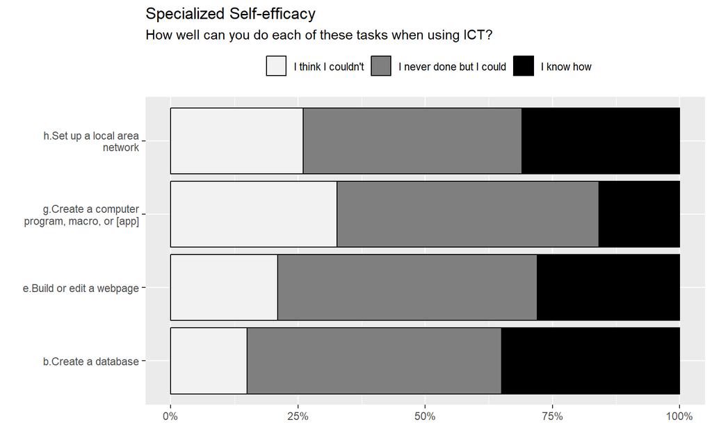

General ICT Self-efficacy

- Edit digital photographs or other graphic images IS2G27A
- Write or edit text for a school assignment IS2G27C
- Search for and find relevant information for a school project on the Internet IS2G27D
- Create a multi-media presentation (with sound, pictures, or video) IS2G27I
- Upload text, images, or video to an online profile IS2G27J
- Insert an image into a document or message IS2G27K
- Install a program or [app] IS2G27L
- Judge whether you can trust information you find on the Internet IS2G27M

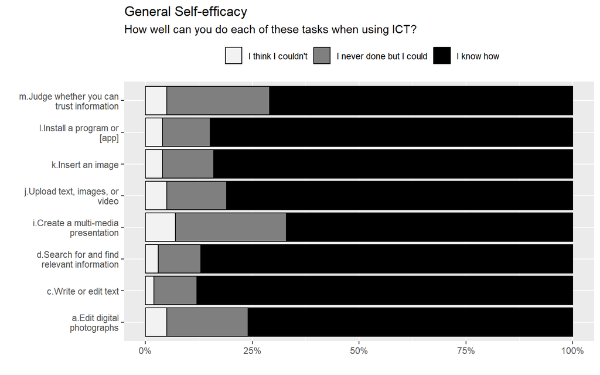

## 0.2 Correlation matrix: assuming continuous

A. Create a database

0.339

0.385

0.316

0.279

0.21

0.187

0.268

0.166

0.18

0.163

0.234

B. Build a webpage

0.501

0.386

0.26

0.168

0.132

0.311

0.177

0.206

0.182

0.23

C. Create a computer program/app

0.512

0.185

0.091

0.06

0.254

0.119

0.136

0.094

0.2

D. Set up a local area network

0.201

0.12

0.122

0.281

0.161

0.157

0.141

0.224

E. Edit graphic images

0.346

0.295

0.346

0.307

0.313

0.262

0.242

F. Write or edit text

0.505

0.29

0.35

0.431

0.358

0.306

G. Search and find information on internet

0.263

0.344

0.393

0.341

0.323

H. Create multi-media presentation

0.344

0.36

0.309

0.304

I. Upload multimedia to an online profile

0.459

0.393

0.323

J. Insert an image into a document/message

0.431

0.338

K. Install a program/app

0.364

L. Judge internet information veracity

## 0.3 Correlation matrix: assuming categorical

A. Create a database

0.423

0.487

0.394

0.404

0.363

0.315

0.349

0.236

0.287

0.248

0.315

B. Build a webpage

0.624

0.48

0.385

0.273

0.221

0.417

0.255

0.295

0.266

0.309

C. Create a computer program/app

0.624

0.275

0.155

0.093

0.36

0.169

0.191

0.149

0.28

D. Set up a local area network

0.305

0.206

0.211

0.379

0.252

0.249

0.215

0.314

E. Edit graphic images

0.541

0.49

0.496

0.471

0.476

0.422

0.355

F. Write or edit text

0.743

0.472

0.559

0.658

0.58

0.495

G. Search and find information on internet

0.43

0.579

0.637

0.572

0.522

H. Create multi-media presentation

0.507

0.537

0.459

0.399

I. Upload multimedia to an online profile

0.678

0.596

0.475

J. Insert an image into a document/message

0.634

0.506

K. Install a program/app

0.524

L. Judge internet information veracity

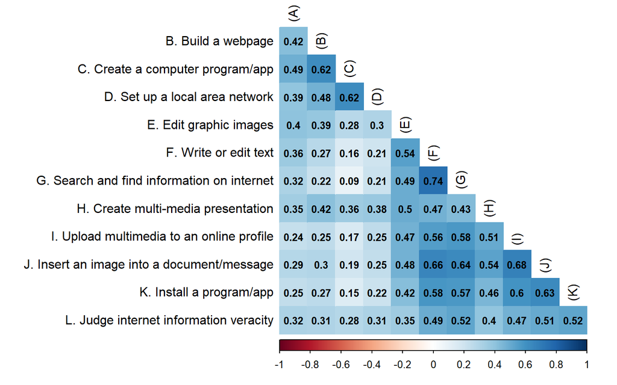

[figure not shown]

## 0.4 Paralel Analyses

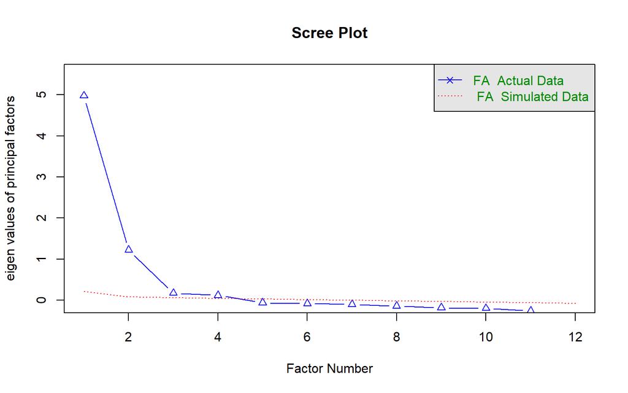

```
## Parallel analysis suggests that the number of factors =  4  and the number of components =  NA
```

## 0.5 EFA considering four factors

```
##
## Loadings:
##                                            PA1    PA2    PA3    PA4
## A. Create a database                       -0.194  0.458  0.405  0.155
## B. Build a webpage                          0.123  0.602         0.142
## C. Create a computer program/app                   0.943
## D. Set up a local area network              0.119  0.656
## E. Edit graphic images                      0.214         0.272  0.448
## F. Write or edit text                                     0.779
## G. Search and find information on internet  0.111         0.785
## H. Create multi-media presentation          0.556  0.211         0.230
## I. Upload multimedia to an online profile   0.805
## J. Insert an image into a document/message  0.688         0.178
## K. Install a program/app                    0.603         0.209
## L. Judge internet information veracity      0.297  0.259  0.358 -0.202
##
##                  PA1   PA2   PA3   PA4
## SS loadings    2.016 2.011 1.671 0.359
## Proportion Var 0.168 0.168 0.139 0.030
## Cumulative Var 0.168 0.336 0.475 0.505
```

[output not shown]

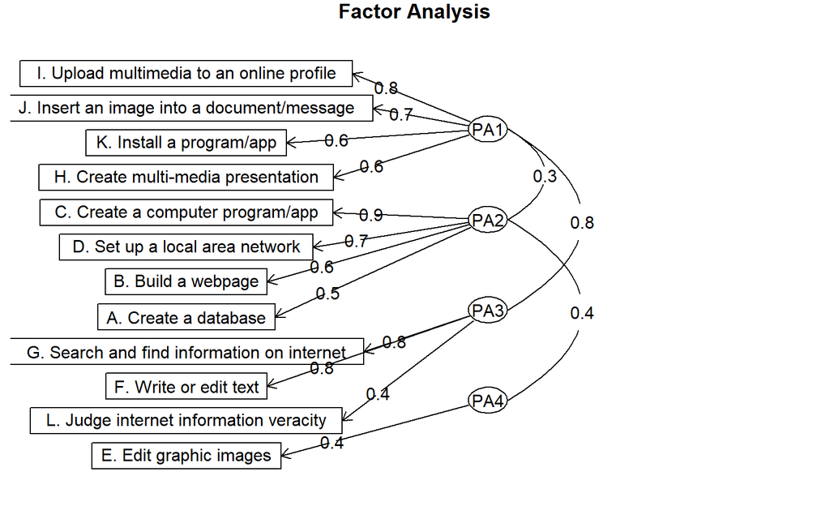

## 0.6 EFA considering three factors

```
##
## Loadings:
##                                            PA1    PA2    PA3
## A. Create a database                       -0.204  0.487  0.471
## B. Build a webpage                                 0.660
## C. Create a computer program/app                   0.912
## D. Set up a local area network              0.142  0.660
## E. Edit graphic images                      0.151  0.230  0.435
## F. Write or edit text                       0.110         0.804
## G. Search and find information on internet  0.239         0.664
## H. Create multi-media presentation          0.457  0.315
## I. Upload multimedia to an online profile   0.817
## J. Insert an image into a document/message  0.720         0.141
## K. Install a program/app                    0.670         0.112
## L. Judge internet information veracity      0.414  0.171  0.188
##
##                  PA1   PA2   PA3
## SS loadings    2.176 2.131 1.586
## Proportion Var 0.181 0.178 0.132
## Cumulative Var 0.181 0.359 0.491
```

[output not shown]

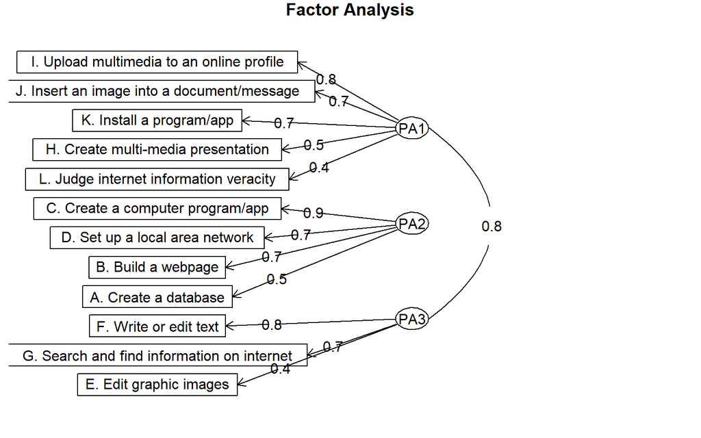

## 0.7 EFA considering two factors

```
##
## Loadings:
##                                            PA1    PA2
## A. Create a database                        0.226  0.485
## B. Build a webpage                          0.131  0.665
## C. Create a computer program/app           -0.102  0.927
## D. Set up a local area network                     0.661
## E. Edit graphic images                      0.541  0.227
## F. Write or edit text                       0.826
## G. Search and find information on internet  0.838
## H. Create multi-media presentation          0.518  0.301
## I. Upload multimedia to an online profile   0.759
## J. Insert an image into a document/message  0.826
## K. Install a program/app                    0.752
## L. Judge internet information veracity      0.573  0.158
##
##                  PA1   PA2
## SS loadings    4.185 2.150
## Proportion Var 0.349 0.179
## Cumulative Var 0.349 0.528
```

Factor Analysis

[output not shown]

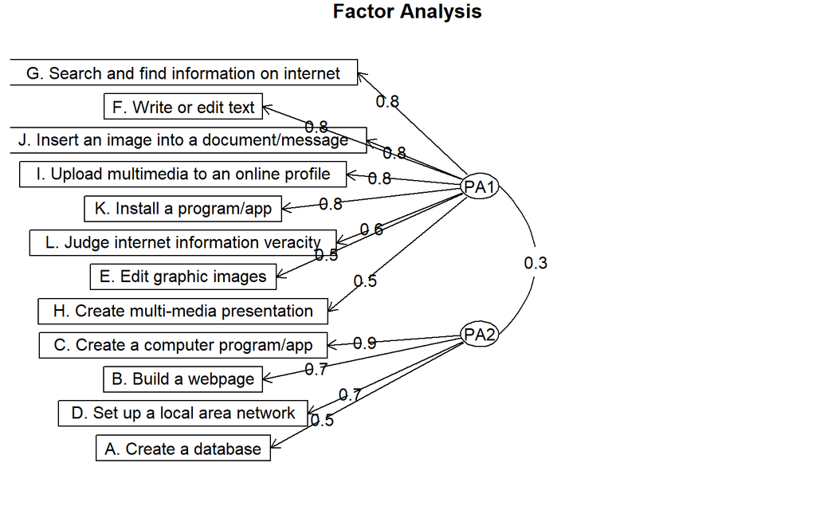